# Predicting Restaurant’s Yelp Star Rating in the U.S.

Min Kang

2023-06-13

## Introduction

This project aims to predict the average number of stars a food establishment in the U.S. will earn on Yelp.

### About our Data Set

According to [Yelp’s website](https://www.yelp.com/dataset), the Yelp Data Set contains a subset of data collected from businesses, reviews, and users for public use. [Documentation](https://www.yelp.com/dataset/documentation/main) reveals that the data set is split into multiple JSON objects: `business.json`, `review.json`, `user.json`, `checkin.json`, `tip.json`, and `photo.json`. For this project, we’ll only have to work with `business.json`.

### Goals

There are many factors that can influence the ratings a restaurant earns. Ideally, I’d like the ratings of a restaurant to prioritize capturing the quality of the food they serve. However, biases, preferences for certain services over others, cultural differences, and many other such opinions people carry sway the results of an establishment’s ratings. The Yelp Data Set fortunately carries meta data on restaurants that allow us to capture some of the qualities of a restaurant aside from their food. Our goal is to see if we can accurately predict the ratings a restaurant will receive using such information. Specifically, this project will focus on establishments that sell prepared food and drinks. We’ll be excluding establishments that primarily sell alcohol from this definition. Defining this right now will help up later in choosing which businesses to include or exclude from our model.

## Loading Packages and Data

We’ll begin by loading all the necessary packages from our library. We’ll also be sure to specify that our code prioritizes the use of tidymodel packages as we are taking advantage of the tidy workflow.

```r
# Load packages

library(dplyr)
library(ggplot2)
library(glmnet)
library(janitor)
library(jsonlite)
library(magrittr)
library(naniar)
library(ranger)
library(readr)
library(rsample)
library(textrecipes)
library(tidyverse)
library(tidymodels)
library(vip)
library(xgboost)

tidymodels_prefer()
```

The yelp JSON objects are initially compiled into one `.tar` file. We’ll have to unravel it to proceed. From there, we’ll load `yelp_academic_dataset.business.json` as a data frame called `business` to start looking into our data.

```r
untar("yelp_dataset.tar")
```

```r
# Read JSON files as character strings
business <- jsonlite::stream_in(file("yelp_academic_dataset_business.json"))
```

[output not shown]

[output cut: 248 more lines]

[output not shown]

## Exploratory Data Analyses/Management

One of `business`’s features is `attributes`. This feature contains valuable information such as the restaurant’s price range, takeout information, accessibility options, and more. However, not all of these attributes are necessarily useful for us, such as `HairSpecializesIn`. In order to make our modeling process simpler to manage and manipulate, we’ll flatten `attributes` so that every attribute becomes its own feature.

```r
# Flatten the nested JSON structure within the attributes column
attributes_df <- jsonlite::flatten(business$attributes)

# Add the flattened attributes as individual columns in the business data frame
business <- business %>%
  select(-attributes) %>%
  bind_cols(attributes_df)
```

### Feature Selection

After flattening `attributes`, we’re left with 52 features and 150346 observations.

```r
dim(business)
```

```
## [1] 150346     52
```

This leaves us with at least two issues we’ll have to handle to move forward.

First, many of these features are irrelevant to our project, like `HairSpecializesIn`; some of these features have enormous amounts of missing data, like `BusinessAccepsBitcoin`; and a few of these features are simply too granular for our model, like `address`. Thus, I’ve chosen to keep features that at a glance are relevant to food establishments, appear to contain significant amounts of data, and are macroscopic enough that they may have significant impact as predictors.

```r
business_clean <- c("name", "city", "is_open", "address", "review_count", "postal_code", "latitude", "longitude", "hours", "BikeParking", "CoatCheck", "BusinessParking", "HappyHour", "HasTV", "GoodForKids", "RestaurantsAttire", "Ambience", "RestaurantsTableService", "RestaurantsGoodForGroups", "NoiseLevel", "GoodForMeal", "BusinessAcceptsBitcoin", "Smoking", "Music", "GoodForDancing", "AcceptsInsurance", "BestNights", "BYOB", "Corkage", "BYOBCorkage", "HairSpecializesIn", "Open24Hours", "RestaurantsCounterService", "AgesAllowed", "DietaryRestrictions", "DriveThru", "Alcohol", "Caters", "DogsAllowed", "ByAppointmentOnly", "WheelchairAccessible")

yelp <- business[, !(names(business) %in% business_clean)]
```

Second, many of these observations do not belong to businesses that serve non-alcoholic prepared food or drinks. These businesses can range from pet care stores, wineries, to automotive services. Luckily, there exists a feature called `categories`. According to [this official Yelp blog post](https://blog.yelp.com/businesses/yelp_category_list/#h-restaurants), categories are labels businesses can pick from to help direct users to their establishment on Yelp. There are over 1,500 different categories to pick from, and businesses are highly encouraged to pick as specific categories as possible. This blog post shows major category groupings such as Active Life, Education, etc., as well as all the possible sub categories to pick from. From this list there are two major categories our project will be concerned with, Food and Restaurants. However, these category lists are not always clean. For example, Food contained backshop as a category. There were also all the alcoholic categories to deal with as well. Thus, I filtered through all the categories and collected all the ones that fit under our project criteria. Finally, I stored all the updated information under `yelp`.

```r
restaurant_categories <- c("Acai Bowls", "Bagels", "Bakeries", "Bento", "Bubble Tea", "Chimney Cakes", "Churros", "Coffee & Tea", "Cupcakes", "Delicatessen", "Desserts", "Donairs", "Donuts", "Empanadas", "Food Trucks", "Friterie", "Gelato", "Hawker Centre", "Honey", "Ice Cream & Frozen Yogurt", "Internet Cafes", "Japanese Sweets", "Taiyaki", "Juice Bars & Smoothies", "Kombucha", "Milkshake Bars", "Nasi Lemak", "Panzerotti", "Parent Cafes", "Patisserie/Cake Shop", "Piadina", "Poke", "Pretzels", "Salumerie", "Shaved Ice", "Shaved Snow", "Smokehouse", "Specialty Food", "Sugar Shacks", "Tea Rooms", "Torshi", "Tortillas", "Zapiekanka", "Afghan", "African", "American (New)", "American (Traditional)", "Andulusian", "Arabian", "Argentine", "Armenian", "Asian Fusion", "Asturian", "Australian", "Austrian", "Baguettes", "Bangladeshi", "Barbeque", "Basque", "Bavarian", "Beisl", "Belfian", "Bistros", "Black Sea", "Brasseries", "Brazillian", "Brazilian Empanadas", "Central Brazillian", "Northeastern Brazillian", "Breakfast & Brunch", "British", "Buffets", "Bulgarian", "Burgers", "Burmese", "Cafes", "Cajun/Creole", "Cambodian", "Canadian (New)", "Caribbean", "Catalan", "Cheesesteaks", "Chicken Shop", "Chicken Wings", "Chilean", "Chinese", "Comfort Food", "Corsican", "Creperies", "Cuban", "Curry Sausage", "Cypriot", "Czech", "Czech/Slovakian", "Danish", "Delis", "Diners", "Dinner Theater", "Dumplings", "Eastern European", "Eritrean", "Ethiopean", "Fast Food", "Filipino", "Fishbroetchen", "Fish & Chips", "Flatbread", "Fondue", "Freiduria", "French", "French Southwest", "Galician", "Gastropubs", "Georgian", "German", "Giblets", "Greek", "Guamanian", "Halal", "Hawaiin", "Heuriger", "Himalayan\\Nepalese", "Honduran", "Hong Kong Style Cafe", "Hot Dogs", "Hot Pot", "Hungarian", "Iberian", "Indian", "Indonesian", "Irish", "Israeli", "Italian", "Japanese", "Jewish", "Kebab", "Kopitiam", "Korean", "Kosher", "Kurdish", "Laos", "Laotian", "Latin American", "Lyonnais", "Malaysian", "Meatballs", "Mediterranean", "Mexican", "Middle Eastern", "Milk Bars", "Modern Australian", "Modern European", "Mongolian", "Moroccan", "New Mexican Cuisine", "New Zealand", "Nicaraguan", "Nikkei", "Norcinerie", "Open Sandwhiches", "Oriental", "Pakistani", "Pan Asian", "Parma", "Persian/Iranian", "Peruvian", "Pita", "Pizza", "Polish", "Polynesian", "Portugese", "Poutineries", "Rice", "Romanian", "Rotisserie Chicken", "Russian", "Salad", "Sandwhiches", "Scandinavian", "Schnitzel", "Scottish", "Seafood", "Serbo Croatian", "Singaporean", "Slovakian", "Somali", "Soul Food", "Southern", "Spanish", "Sri Lankan", "Steakhouses", "Supper Clubs", "Sushi Bars", "Swabian", "Swedish", "Swiss Food", "Syrian", "Tabernas", "Taiwanese", "Tapas Bars", "Tapas/Small Plates", "Tavola Calda", "Tex-Mex", "Thai", "Traditional Norwegian", "Traditional Swedish", "Trattoerie", "Turkish", "Ukrainian", "Uzbek", "Vegan", "Vegetarian", "Venison", "Vietnamese", "Waffles", "Wok", "Wraps", "Yusoslav")

yelp$is_restaurant <- grepl(paste(restaurant_categories, collapse = "|"), yelp$categories, ignore.case = TRUE)

yelp <- yelp[yelp$is_restaurant, ]
```

It wouldn’t be useful to simply have all the filtered categories exist as predictors for our model. The sheer quantity of them would make our model run inefficiently, and their granularity would make them poor predictors. Thus, I chose 7 different food/drink features to place all of these categories under. These boolean features are African, Asian, Cafes/Desserts, European, Latin American, Middle Eastern, and North American. I went through all of the filtered categories and hand placed them under the appropriate feature. Now instead of listing the restaurant’s category, the data frame shows which major restaurant group they do or do not belong to.

```r
# Define the restaurant groups
restaurant_groups <- c(
  "African",
  "Asian",
  "Cafes/Desserts",
  "European",
  "Latin American",
  "Middle Eastern",
  "North American"
)

# Create an empty list to store the category mapping
group_mapping <- list()

# Define the category mapping for each group
group_mapping$African <- c("Afghan", "African", "Eritrean", "Ethiopean", "Nicaraguan", "Somali")
group_mapping$Asian <- c("Bento", "Hawker Centre", "Taiyaki", "Nasi Lemak", "Poke", "Asian Fusion", "Bangladeshi", "Burmese", "Cambodian", "Chinese", "Dumplings", "Filipino", "Guamanian", "Himalayan\\Nepalese", "Hong Kong Style Cafe", "Hot Pot", "Indian", "Indonesian", "Japanese", "Kopitiam", "Korean", "Laos", "Laotian", "Malaysian", "Mongolian", "Nikkei", "Oriental", "Pan Asian", "Polynesian", "Rice", "Singaporean", "Sri Lankan", "Sushi Bars", "Taiwanese", "Thai", "Vietnamese", "Wok")
group_mapping$`Cafes/Desserts` <- c("Acai Bowls", "Bagels", "Bakeries", "Bubble Tea", "Chimney Cakes", "Churros", "Coffee & Tea", "Cupcakes", "Desserts", "Donuts", "Gelato", "Honey", "Ice Cream & Frozen Yogurt", "Internet Cafes", "Japanese Sweets", "Juice Bars & Smoothies", "Kombucha", "Milkshake Bars", "Parent Cafes", "Patisserie/Cake Shop", "Shaved Ice", "Shaved Snow", "Sugar Shacks", "Tea Rooms", "Breakfast & Brunch", "Cafes", "Cheesesteaks", "Creperies", "Milk Bars")
group_mapping$European <- c("Delicatessen", "Friterie", "Panzerotti", "Piadina", "Pretzels","Salumerie", "Torshi", "Zapiekanka", "Andulusian", "Armenian", "Asturian", "Australian", "Austrian", "Baguettes", "Basque", "Bavarian", "Beisl", "Belfian", "Bistros", "Black Sea", "Brasseries", "British", "Bulgarian", "Catalan", "Corsican", "Curry Sausage", "Cypriot", "Czech", "Czech/Slovakian", "Danish", "Eastern European", "Fishbroetchen", "Fish & Chips", "Fondue", "Freiduria", "French", "French Southwest", "Galician", "Gastropubs", "Georgian", "German", "Giblets", "Greek",
  "Heuriger", "Hungarian", "Iberian", "Irish", "Italian", "Lyonnais", "Meatballs", "Mediterranean", "Modern Australian", "Modern European", "New Zealand", "Norcinerie", "Parma", "Polish", "Portugese", "Romanian", "Russian", "Scandinavian", "Schnitzel", "Scottish", "Serbo Croatian", "Slovakian", "Spanish", "Swabian", "Swedish", "Swiss Food", "Tabernas", "Tapas Bars", "Tapas/Small Plates", "Tavola Calda", "Traditional Norwegian", "Traditional Swedish", "Trattoerie", "Turkish", "Ukrainian", "Uzbeck", "Venison", "Yusoslav")
group_mapping$`Latin American` <- c("Empanadas", "Tortillas", "Argentine", "Brazillian", "Brazilian Empanadas", "Central Brazillian", "Northeastern Brazillian", "Caribbean", "Chilean", "Cuban", "Latin American", "Mexican", "New Mexican Cuisine", "Peruvian")
group_mapping$`Middle Eastern` <- c("Arabian", "Flatbread", "Halal", "Israeli", "Jewish", "Kebab", "Kosher", "Kurdish", "Moroccan", "Pakistani", "Persian/Iranian", "Pita", "Syrian")
group_mapping$`North American` <- c("Donairs", "Food Trucks", "Smokehouse", "Specialty Food", "American (New)", "American (Traditional)", "Barbeque", "Buffets", "Burgers", "Cajun/Creole", "Canadian (New)", "Chicken Shop", "Chicken Wings", "Comfort Food", "Delis", "Diners", "Dinner Theater", "Fast Food", "Hawaiin", "Honduran", "Hot Dogs", "Open Sandwhiches", "Pizza", "Poutineries", "Rotisserie Chicken", "Salad", "Sandwhiches", "Seafood", "Soul Food", "Southern", "Steakhouses", "Supper Clubs", "Tex-Mex", "Vegan", "Vegetarian", "Waffles", "Wraps")

# Create new columns for each category
for (group in restaurant_groups) {
  categories <- group_mapping[[group]]
  yelp[[group]] <- grepl(paste(categories, collapse = "|"), yelp$categories, ignore.case = TRUE)
}

# Remove the 'categories' and 'is_restaurant' columns
yelp <- yelp[, !(names(yelp) %in% c("categories", "is_restaurant"))]
```

### Normalizing values

Due to the nature of the Yelp Data Set, all of our predictors are nominal. Many of them are boolean in nature. However, the values they take on to represent the same things can differ from predictor to predictor. Many of these predictors show `none`, `u'no'`, and `False` just to represent the same outcome. So, we apply a function to normalize value outcomes to prevent our model from misinterpreting the data.

```r
# Get unique values of the predictors
BusinessAcceptsCreditCards_values <- unique(yelp$BusinessAcceptsCreditCards)
RestaurantReservations_values <- unique(yelp$RestaurantsReservations)
WiFi_values <- unique(yelp$WiFi)
RestaurantsTakeOut_values <- unique(yelp$RestaurantsTakeOut)
RestaurantsDelivery_values <- unique(yelp$RestaurantsDelivery)
OutdoorSeating_values <- unique(yelp$OutdoorSeating)

# Print the unique values
print(BusinessAcceptsCreditCards_values)
```

```
## [1] NA      "False" "True"  "None"
```

```r
print(RestaurantReservations_values)
```

```
## [1] NA      "False" "True"  "None"
```

```r
print(WiFi_values)
```

```
## [1] NA        "u'free'" "u'no'"   "'free'"  "'no'"    "'paid'"  "None"
## [8] "u'paid'"
```

```r
print(RestaurantsTakeOut_values)
```

```
## [1] NA      "True"  "None"  "False"
```

```r
print(RestaurantsDelivery_values)
```

```
## [1] NA      "False" "True"  "None"
```

```r
print(OutdoorSeating_values)
```

```
## [1] NA      "False" "True"  "None"
```

```r
# Define a function to normalize predictors
normalize <- function(value) {
    if (value %in% c("u'free'", "'free'")) {
    return("Free")
  } else if (value %in% c("u'paid'", "'paid'")) {
    return("Paid")
  } else if (value %in% c("None", "False", "u'no'", "no", "FALSE")) {
    return("false")
  } else if (value %in% c("True", "TRUE")) {
    return("true")
  } else {
    return(value)
  }
}

# Apply the normalization function
yelp$BusinessAcceptsCreditCards <- sapply(yelp$BusinessAcceptsCreditCards, normalize)
print(BusinessAcceptsCreditCards_values)
```

```
## [1] NA      "False" "True"  "None"
```

```r
yelp$RestaurantsReservations <- sapply(yelp$RestaurantsReservations, normalize)
print(RestaurantReservations_values)
```

```
## [1] NA      "False" "True"  "None"
```

```r
yelp$WiFi <- sapply(yelp$WiFi, normalize)
print(WiFi_values)
```

```
## [1] NA        "u'free'" "u'no'"   "'free'"  "'no'"    "'paid'"  "None"
## [8] "u'paid'"
```

```r
yelp$RestaurantsTakeOut <- sapply(yelp$RestaurantsTakeOut, normalize)
print(RestaurantsTakeOut_values)
```

```
## [1] NA      "True"  "None"  "False"
```

```r
yelp$RestaurantsDelivery <- sapply(yelp$RestaurantsDelivery, normalize)
print(RestaurantsDelivery_values)
```

```
## [1] NA      "False" "True"  "None"
```

```r
yelp$OutdoorSeating <- sapply(yelp$OutdoorSeating, normalize)
print(OutdoorSeating_values)
```

```
## [1] NA      "False" "True"  "None"
```

```r
yelp$African <- sapply(yelp$African, normalize)
yelp$Asian <- sapply(yelp$Asian, normalize)
yelp$`Cafes/Desserts` <- sapply(yelp$`Cafes/Desserts`, normalize)
yelp$European <- sapply(yelp$European, normalize)
yelp$`Latin American` <- sapply(yelp$`Latin American`, normalize)
yelp$`Middle Eastern` <- sapply(yelp$`Middle Eastern`, normalize)
yelp$`North American` <- sapply(yelp$`North American`, normalize)
```

### Converting Factors

Since all of our predictors are discrete, with only our outcome being continuous, we factorize all of our predictors.

```r
yelp$business_id <- as.factor(yelp$business_id)
yelp$state <- as.factor(yelp$state)
yelp$BusinessAcceptsCreditCards <- as.factor(yelp$BusinessAcceptsCreditCards)
yelp$RestaurantsPriceRange2 <- as.factor(yelp$RestaurantsPriceRange2)
yelp$RestaurantsTakeOut <- as.factor(yelp$RestaurantsTakeOut)
yelp$RestaurantsDelivery <- as.factor(yelp$RestaurantsDelivery)
yelp$WiFi <- as.factor(yelp$WiFi)
yelp$OutdoorSeating <- as.factor(yelp$OutdoorSeating)
yelp$RestaurantsReservations <- as.factor(yelp$RestaurantsReservations)
yelp$African <- as.factor(yelp$African)
yelp$Asian <- as.factor(yelp$Asian)
yelp$`Cafes/Desserts` <- as.factor(yelp$`Cafes/Desserts`)
yelp$European <- as.factor(yelp$European)
yelp$`Latin American` <- as.factor(yelp$`Latin American`)
yelp$`Middle Eastern` <- as.factor(yelp$`Middle Eastern`)
yelp$`North American` <- as.factor(yelp$`North American`)

head(yelp)
```

```
##               business_id state stars BusinessAcceptsCreditCards
## 1  Pns2l4eNsfO8kk83dixA6A    CA   5.0                       <NA>
## 4  MTSW4McQd7CbVtyjqoe9mw    PA   4.0                      false
## 6  CF33F8-E6oudUQ46HnavjQ    TN   2.0                       true
## 9  k0hlBqXX-Bt0vf1op7Jr1w    MO   3.0                       true
## 10 bBDDEgkFA1Otx9Lfe7BZUQ    TN   1.5                       true
## 12 eEOYSgkmpB90uNA7lDOMRA    FL   4.0                       <NA>
##    RestaurantsPriceRange2 RestaurantsTakeOut RestaurantsDelivery  WiFi
## 1                    <NA>               <NA>                <NA>  <NA>
## 4                       1               true               false  Free
## 6                       1               true                true false
## 9                       1               true               false  Free
## 10                      1               true                true false
## 12                   <NA>               <NA>                <NA>  <NA>
##    OutdoorSeating RestaurantsReservations African Asian Cafes/Desserts European
## 1            <NA>                    <NA>   false  true          false    false
## 4           false                    <NA>   false false           true    false
## 6            true                   false   false false           true    false
## 9            true                   false   false false          false     true
## 10           true                   false   false false           true    false
## 12          false                   false   false  true          false    false
##    Latin American Middle Eastern North American
## 1           false          false          false
## 4           false          false          false
## 6           false          false           true
## 9           false          false          false
## 10          false          false           true
## 12          false          false           true
```

### Missing Data

A necessary step to move forward is to look for missing data. We can observe that `WiFi` and `RestaurantReservations` are the two features left with the highest percentage of missing data. Since both of these features are not expected of all food/drink establishments, e.g.) it’s unlikely any boba store would require reservations, we can simply omit these features from the model.

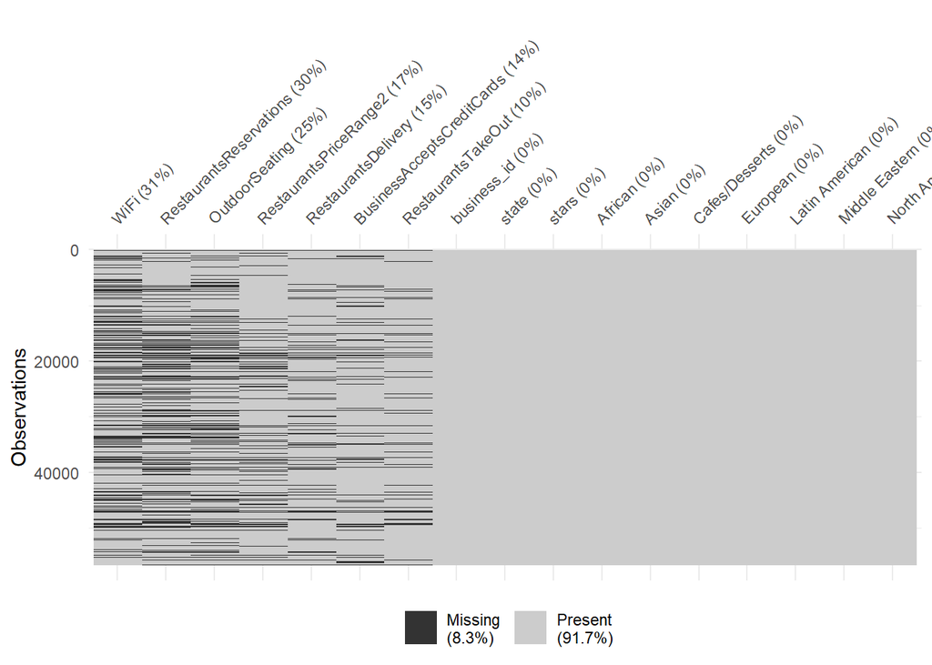

```r
yelp %>% vis_miss(warn_large_data = FALSE, sort_miss = TRUE)
```

The rest of our missing data is now small enough that imputation becomes a more viable solution. Since the predictors with missing data are nominal, we’ll choose to impute with mode. This will be done later in our recipe creation.

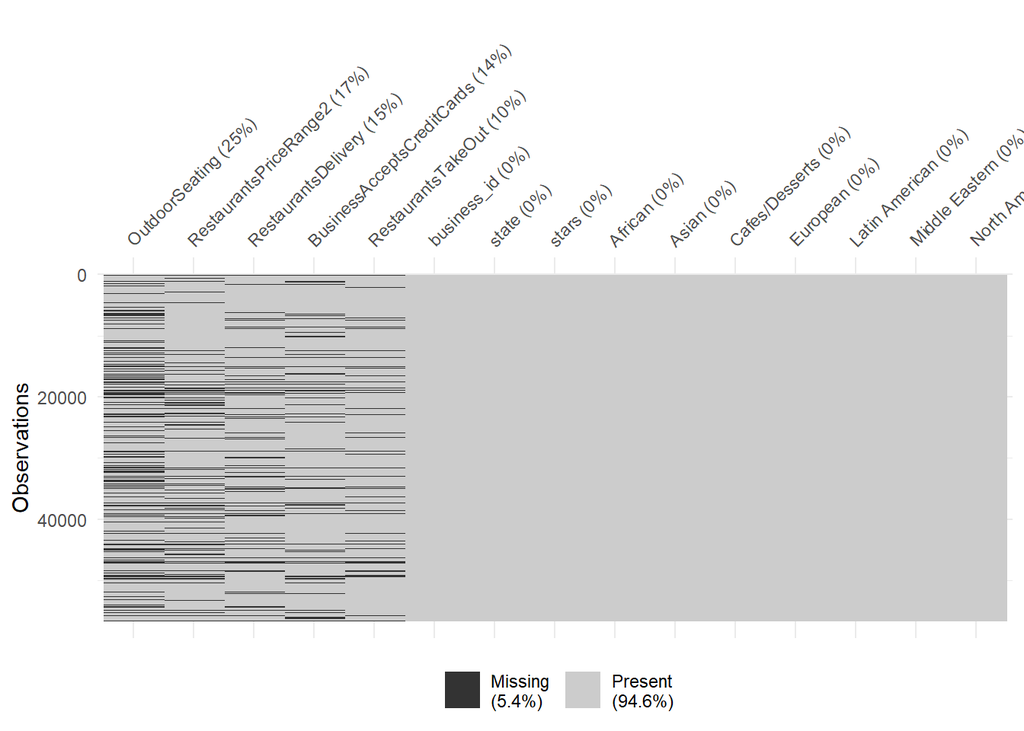

```r
yelp <- yelp[, !(names(yelp) %in% c("WiFi", "RestaurantsReservations"))]
yelp %>% vis_miss(warn_large_data = FALSE, sort_miss = TRUE)
```

### Visual Data Exploration

It may be helpful to see the distribution of our outcome. We can see here that the mean distribution of stars is left skewed. This suggests that there exists a factor that encourages people to rank restaurants more favorably. Hopefully, our model captures this.

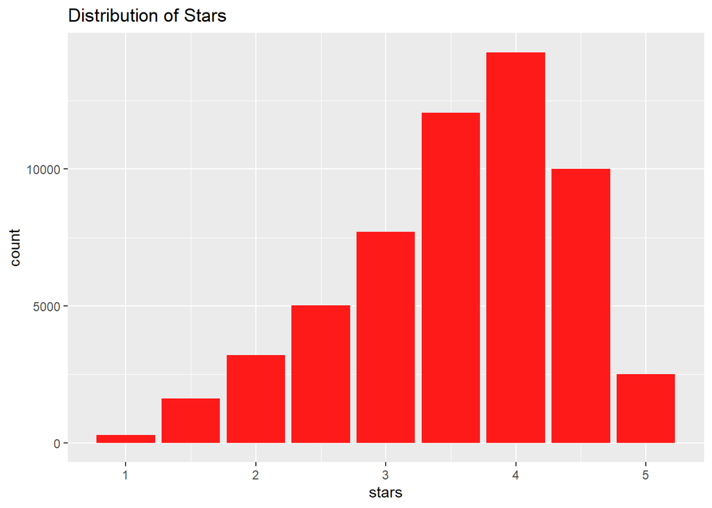

```r
ggplot(yelp, aes(stars)) +
  geom_bar(fill = rgb(255, 26, 26, maxColorValue = 255)) +
  labs(title = "Distribution of Stars")
```

We should also see what the distribution of restaurants in the U.S. are according to our definitions. Unsurprisingly, a majority of the restaurants are classified as North American, this is despite European containing significantly more categories. It also appears there aren’t many Middle Eastern or African restaurants in the U.S.

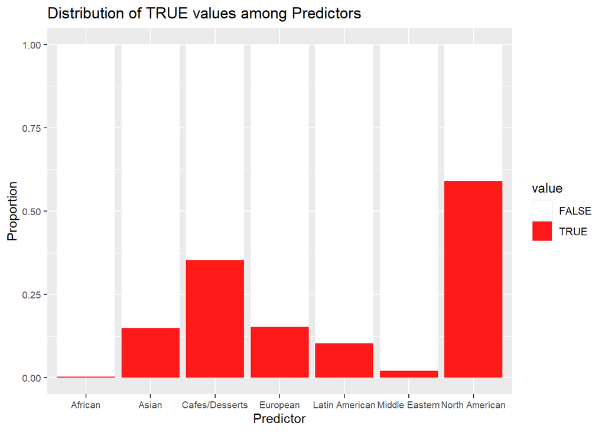

```r
# Reshape the data frame to long format
yelp_long <- tidyr::pivot_longer(yelp, cols = c(African, Asian, `Cafes/Desserts`, European, `Latin American`, `Middle Eastern`, `North American`))

# Create a bar plot
ggplot(yelp_long, aes(x = name, fill = value)) +
  geom_bar(position = "fill") +
  scale_fill_manual(values = c("#FFFFFF", "#FF1A1A"), labels = c("FALSE", "TRUE")) +
  labs(x = "Predictor", y = "Proportion", title = "Distribution of TRUE values among Predictors") +
  theme(axis.text = element_text(size = 8))
```

## Model Preperation

Before we begin creating our model, we’ll set the seed for the sake of reproducibility.

```r
set.seed(92)
```

We’ll now split our data frame into a training and testing set. The training set will serve to build our models. We’ll then assess the models based off their RMSE, root mean squared error, scores. Our testing set will serve to compare the results of our models on a portion of data it has never seen before. This will allow us to see if we’ve over or under-fitted our model. I’ve chosen to use a 70% of the data for the training set and 30% of the data for the testing set. The objective here is to strike a good balance of giving our models as much training data as possible while still having enough data left for our testing test to make meaningful comparisons to. Having our testing set being proportionately smaller will allow us to observe any over or under-fitting that may occur. We’ll stratify our data on our outcome `stars`. Thus, we can be assured there is an equal proportion of our outcome variable in both the testing and training set. We can also observe if our data was split as intended.

```r
yelp_split <- initial_split(yelp, prop = 0.70, strata = stars)
yelp_train <- training(yelp_split)
yelp_test <- testing(yelp_split)

nrow(yelp_train)/nrow(yelp)
```

```
## [1] 0.6999682
```

```r
nrow(yelp_test)/nrow(yelp)
```

```
## [1] 0.3000318
```

### Recipe Formulation

Our recipe also requires several other crucial steps. `step_zv()` removes any zero variance predictors. That is, it’ll remove any predictors that have no influence on the outcome of our models. We’ll also impute the predictors with missing data from earlier with `step_impute_mode()`. Since our predictors are categorical, `step_dummy()` will convert our predictors into indicator variables for our models to be able to interpret.

```r
yelp_recipe <- recipe(yelp_train) %>%

  update_role(all_nominal(), new_role = "id") %>%

  update_role(stars, new_role = "outcome") %>%

  update_role(state, BusinessAcceptsCreditCards, RestaurantsTakeOut, RestaurantsDelivery, OutdoorSeating, African, Asian, `Cafes/Desserts`, European, `Latin American`, `Middle Eastern`, `North American`, new_role = "predictor") %>%

  step_zv(all_nominal_predictors()) %>%

  step_impute_mode(all_nominal(), -all_outcomes()) %>%

  step_dummy(state, BusinessAcceptsCreditCards, RestaurantsTakeOut, RestaurantsDelivery, OutdoorSeating, African, Asian, `Cafes/Desserts`, European, `Latin American`, `Middle Eastern`, `North American`) %>%

  step_center(all_predictors()) %>%
  step_scale(all_predictors())
```

### K-Fold Cross Validation

Our models will take advantage of k-fold cross validation. That is, our data split into 9 different folds. Our models will be trained on 8 of the 9 folds and tested against the remaining fold. This will occur 9 times, and we’ll take the average metrics across the 9 runs to measure our model performance. Similar to how we stratified our data on `stars` during the split earlier, we’ll do the same when creating these folds. Cross validation is a useful tool in observing the bias-variance trade offs of our model as well as increasing our model’s overall robustness.

```r
yelp_folds <- vfold_cv(yelp_train, v = 9, strata = stars)
```

## Model Building

We’ll now design the models for our experiment. Since our outcome is continuous, we’ll be building regression models. We’ll also choose RMSE as our metric for evaluation when picking our best models. That is, we’ll pick the model with the lowest overall RMSE. The models of choice are linear regression, ridge regression, lasso regression, k-nearest neighbors, and xgboost.

```r
linear <- linear_reg() %>%
  set_engine("lm")

ridge <- linear_reg(mixture = 0, penalty = tune()) %>%
  set_mode("regression") %>%
  set_engine("glmnet")

lasso <- linear_reg(mixture = 1, penalty = tune()) %>%
  set_mode("regression") %>%
  set_engine("glmnet")

knn <- nearest_neighbor(neighbors = tune()) %>%
  set_mode("regression") %>%
  set_engine("kknn")

bt <- boost_tree(trees = tune(), learn_rate = tune(), min_n = tune()) %>%
  set_engine("xgboost") %>%
  set_mode("regression")
```

Here, we’ll design the workflows for our models using our models and recipe.

```r
linear_wf <- workflow() %>%
  add_model(linear) %>%
  add_recipe(yelp_recipe)

ridge_wf <- workflow() %>%
  add_model(ridge) %>%
  add_recipe(yelp_recipe)

lasso_wf <- workflow() %>%
  add_model(lasso) %>%
  add_recipe(yelp_recipe)

knn_wf <- workflow() %>%
  add_model(knn) %>%
  add_recipe(yelp_recipe)

bt_wf <- workflow() %>%
  add_model(bt) %>%
  add_recipe(yelp_recipe)
```

Here we’ll create tuning grids to set the parameters for model tuning.

```r
penalty_grid <- grid_regular(penalty(range = c(-5, 5)), levels = 50)

neighbors_grid <- grid_regular(neighbors(range = c(1, 15)), levels = 5)

bt_grid <- grid_regular(trees(range = c(5, 200)), learn_rate(range = c(0.01, 0.1), trans = identity_trans()), min_n(range = c(40, 60)), levels = 5)
```

We’ll now tune the models specifying our workflows, folds, and tuning grids.

```r
# linear regression does not require tuning
linear_fit <- fit_resamples(linear_wf, resamples = yelp_folds)

ridge_tune <- tune_grid(ridge_wf, resamples = yelp_folds, grid = penalty_grid)

lasso_tune <- tune_grid(lasso_wf, resamples = yelp_folds, grid = penalty_grid)

knn_tune <- tune_grid(knn_wf, resamples = yelp_folds, grid = neighbors_grid)

bt_tune <- tune_grid(bt_wf, resamples = yelp_folds, grid = bt_grid)
```

We’ll now read and write these models into our project directory to save computation time.

```r
write_rds(linear_fit, file = "tuned_models/linear.rds")
write_rds(ridge_tune, file = "tuned_models/ridge.rds")
write_rds(lasso_tune, file = "tuned_models/lasso.rds")
write_rds(knn_tune, file = "tuned_models/knn.rds")
write_rds(bt_tune, file = "tuned_models/bt.rds")
```

```r
linear_fit <- read_rds(file = "tuned_models/linear.rds")
ridge_tune <- read_rds(file = "tuned_models/ridge.rds")
lasso_tune <- read_rds(file = "tuned_models/lasso.rds")
knn_tune <- read_rds(file = "tuned_models/knn.rds")
bt_tune <- read_rds(file = "tuned_models/bt.rds")
```

## Model Results

```r
linear_rmse <- show_best(linear_fit, metrics = "rmse")[1,]

ridge_rmse <- show_best(ridge_tune, metrics = "rmse")[1,]

lasso_rmse <- show_best(lasso_tune, metrics = "rmse")[1,]

knn_rmse <- show_best(knn_tune, metrics = "rmse")[1,]

bt_rmse <- show_best(bt_tune, metrics = "rmse")[1,]
```

We can see that our boosted trees model performed the best. Ridge regression, lasso regression, and linear regression all performed similarly to one another, and was also only marginally worse than boosted trees. However, k-nearest neighbors clearly performed the worst. This could be due to the imbalance of restaurants in the U.S..

```r
final_tibble <- tibble(Model = c("Linear Regression", "Ridge Regression", "Lasso Regression","K Nearest Neighbors", "Boosted Trees"), RMSE = c(linear_rmse$mean, ridge_rmse$mean, lasso_rmse$mean, knn_rmse$mean, bt_rmse$mean))

# Arranging by lowest RMSE
final_tibble <- final_tibble %>%
  arrange(RMSE)

print(final_tibble)
```

```
## # A tibble: 5 × 2
##   Model                RMSE
##   <chr>               <dbl>
## 1 Boosted Trees       0.812
## 2 Ridge Regression    0.829
## 3 Lasso Regression    0.829
## 4 Linear Regression   0.829
## 5 K Nearest Neighbors 1.20
```

### Best Model Visualization

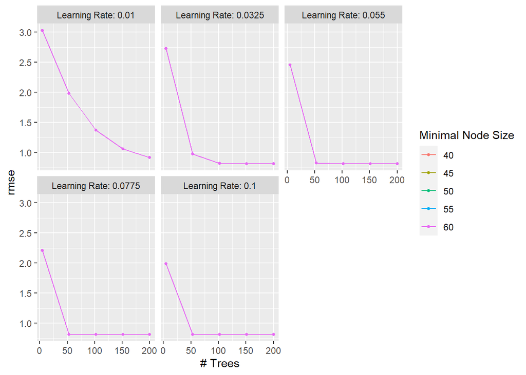

```r
autoplot(bt_tune, metric = "rmse")
```

### Model Testing

First, we select the best xgboost model to fit onto the entirety of our training data.

```r
best_bt_train <- select_best(bt_tune, metric = "rmse")
bt_final_workflow_train <- finalize_workflow(bt_wf, best_bt_train)
bt_final_fit_train <- fit(bt_final_workflow_train, data = yelp_train)

write_rds(bt_final_fit_train, file = "bt_final/bt_final_train.rds")
```

Then, we test the model on our testing set.

```r
yelp_tibble <- predict(bt_final_fit_train, new_data = yelp_test %>% select(-stars))
yelp_tibble <- bind_cols(yelp_tibble, yelp_test %>% select(stars))
```

The RMSE of the testing set, 0.8159, performed slightly worse than the training set, 0.8125. It is important to note that the values RMSE take on are in relation to the scale of the outcome. Since Yelp rates from 0 to 5 stars, an RMSE of 0.8159 is not an ideal score. Our model is only able to account for some of the variation in the account.

```r
yelp_metric <- metric_set(rmse)

yelp_tibble_metrics <- yelp_metric(yelp_tibble, truth = stars, estimate = .pred)
yelp_tibble_metrics
```

```
## # A tibble: 1 × 3
##   .metric .estimator .estimate
##   <chr>   <chr>          <dbl>
## 1 rmse    standard       0.816
```

The plot of our predicted vs. actual values is somewhat illuminating to what is occurring. It seems our model likes to predict that just about restaurant will like to sit somewhere close to the 3-4 star range. This aligns fairly close with the distribution of stars we observed earlier. However, the model seems to do a poor job of predicting when a restaurant will receive a low rating.

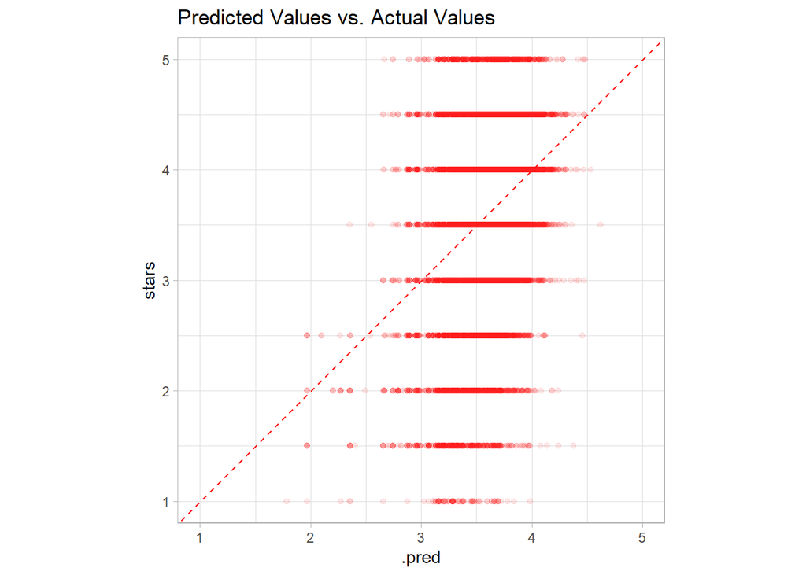

```r
yelp_tibble %>%
  ggplot(aes(x = .pred, y = stars)) +
  geom_point(alpha = 0.1, color = rgb(255, 26, 26, maxColorValue = 255)) +
  geom_abline(lty = 2, color = rgb(255, 26, 26, maxColorValue = 255)) +
  coord_obs_pred() +
  theme_light() +
  labs(title = "Predicted Values vs. Actual Values")
```

### Variable Importance Plot

Since xgboost was our best model, we’re able to use a VIP, variable important plot, to observe the most significant predictors in our outcome. Whether or not a restaurant was `North American_true` is by far our best predictor, but that could be due to the sheer number of restaurants that were North American. Our second best predictor is `RestaurantsDelivery_true`. This indicates that the most important service a restaurant can offer for their ratings is if they deliver or not.

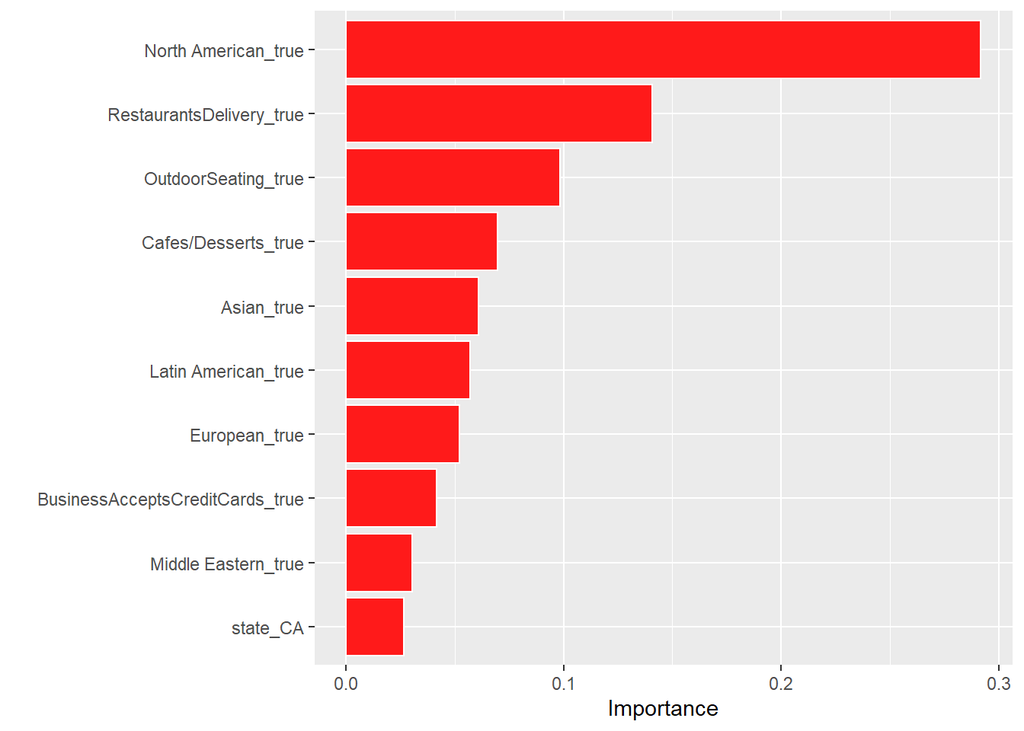

```r
bt_final_fit_train %>%
  extract_fit_engine() %>%
  vip(aesthetics = list(fill = rgb(255, 26, 26, maxColorValue = 255), color = "white"))
```

## Conclusion

After running our models, it seems it would be difficult to gauge using Yelp meta data alone to predict the average stars a restaurant will receive. After testing out several models, xgboost resulted in the lowest RMSE compared to the others, but not by a lot. None of the models had particularly strong RMSE scores either.

Model improvements could definitely be made with perhaps longer training times or finer tuning, but I think the biggest losses, or in this case gains, in RMSE was due to how much data was lost between all the features we were forced to exclude. The Yelp Data Set also contains but a subset of their data base, and I am unsure if this data was stratified evenly across all features. Would it have been possible to obtain more observations on restaurants that exist outside of the North American category. There also could be significant sources of error in how I chose to group restaurants, and even more error exists when thinking about how well businesses chose to categorize themselves.

If I were to iterate on this project, I would look into analyzing `review.json`. Perhaps sentiment analysis would be able to capture reviewers thoughts more robustly than a star system ever could. It might also be worth the effort to categorize users based off user meta data. Perhaps the ratings a user gives is more dependent on the user than the establishment they go to.

For the purposes of my research question, the outcome of this project, although not perfectly concluded, is reassuring to observe. Since there is no direct business meta data on the quality of food, the fact we weren’t able to strongly predict ratings accurately suggests a possibility that food quality is an important feature of a restaurant’s rating that we failed to capture. Thus, for now, I can be rest assured that perhaps I can dine happily at a highly rated Yelp restaurant.

## Sources

The data comes from the [Yelp Dataset](https://www.yelp.com/dataset/documentation/main) and its documentation can be found [here](https://www.yelp.com/dataset/documentation/main)

The [official Yelp blog post](https://blog.yelp.com/businesses/yelp_category_list/#h-restaurants) contains all the information related to categories.

[Brand Palletes](https://brandpalettes.com/yelp-colors/) gave information on Yelp colors for plot purposes.